# Trading and investment account summary

# For 2020-08-27

Summary text: The equity value of my live trading portfolio changed by 0.54 % (US$ 188.31 ) from US$ 35087.41 to US$ 35275.72 today ( 2020-08-27 ). The trading proceeds in my live account were US$ 101.02 . The book proceeds in my portfolio changed from US$ 2033.1 to US$ 2120.39

## Portfolio

The below table shows the current positions in the live account as well as their current and total performance. “book_proceed” indicates the unrealized profit in that position.

| symbol | close | closePerc | Total_Change_close | entry_price | position | position_size | entry_position | totalPerc | book_proceed | sector |
| --- | --- | --- | --- | --- | --- | --- | --- | --- | --- | --- |
| KWEB | 70.94 | -0.28 | -17 | 69.95 | 85 | 6029.90 | 5946.12 | 1.39 | 83.78 | Miscellaneous |
| BRK.B | 216.89 | 1.03 | 55.5 | 195.40 | 25 | 5422.25 | 4885.08 | 9.91 | 537.17 | Finance |
| SEAS | 20.56 | 4.63 | -182 | 18.93 | -200 | -4112.00 | -3786.61 | -7.91 | -325.39 | Consumer Services |
| EZA | 38.11 | -1.06 | 30.75 | 38.54 | -75 | -2858.25 | -2890.50 | 1.13 | 32.25 | Miscellaneous |
| CAKE | 28.42 | 4.91 | 117.04 | 23.83 | 88 | 2500.96 | 2097.05 | 16.15 | 403.91 | Consumer Services |
| TSLA | 2239.76 | 4.08 | 87.83 | 1405.56 | 1 | 2239.76 | 1405.56 | 37.25 | 834.2 | Consumer Durables |
| SQ | 155.62 | 1.18 | 23.66 | 141.33 | 13 | 2023.06 | 1837.35 | 9.18 | 185.71 | Technology Services |
| INDA | 33.91 | 0.1 | 1.75 | 33.05 | 50 | 1695.25 | 1652.50 | 2.52 | 42.75 | Miscellaneous |
| GOOG | 1635.31 | -1.01 | -16.67 | 1599.21 | 1 | 1635.31 | 1599.21 | 2.21 | 36.1 | Technology Services |
| TPR | 14.90 | 0.4 | 5.1 | 14.96 | 85 | 1266.50 | 1271.99 | -0.43 | -5.49 | Retail Trade |
| SLV | 25.17 | -1.57 | -19.23 | 22.79 | 48 | 1208.13 | 1093.73 | 9.47 | 114.4 | Miscellaneous |
| MIK | 10.81 | -2.52 | -28 | 8.51 | 100 | 1081.00 | 851.26 | 21.25 | 229.74 | Retail Trade |
| UNM | 18.84 | 2.56 | 23.5 | 19.21 | 50 | 942.00 | 960.30 | -1.94 | -18.3 | Finance |
| RVLV | 19.84 | -1.15 | -8.74 | 18.07 | 38 | 753.92 | 686.53 | 8.94 | 67.39 | Retail Trade |
| CAT | 143.41 | 1.11 | 7.9 | 142.04 | 5 | 717.05 | 710.20 | 0.96 | 6.85 | Producer Manufacturing |
| GOLD | 28.58 | -2.69 | -19.75 | 28.06 | 25 | 714.50 | 701.56 | 1.81 | 12.94 | Non-Energy Minerals |
| SWKS | 140.17 | -1.77 | -12.6 | 131.85 | 5 | 700.85 | 659.25 | 5.94 | 41.6 | Electronic Technology |
| IAU | 18.42 | -1.18 | -8.36 | 19.00 | 38 | 699.96 | 722.00 | -3.15 | -22.04 | Miscellaneous |
| PPLT | 87.02 | -1.39 | -9.84 | 89.44 | 8 | 696.16 | 715.49 | -2.78 | -19.33 | Miscellaneous |
| EPHE | 26.52 | -1.39 | 9.38 | 25.67 | -25 | -663.12 | -641.70 | -3.23 | -21.42 | Miscellaneous |
| DGX | 110.02 | -7.02 | -49.86 | 106.85 | 6 | 660.12 | 641.10 | 2.88 | 19.02 | Health Services |
| V | 211.08 | 0.39 | 2.43 | 194.66 | 3 | 633.24 | 583.99 | 7.78 | 49.25 | Finance |
| PALL | 205.05 | -0.76 | -4.71 | 219.68 | 3 | 615.15 | 659.04 | -7.13 | -43.89 | Miscellaneous |
| DBX | 20.30 | -1.36 | -8.4 | 20.73 | 30 | 609.00 | 621.75 | -2.09 | -12.75 | Technology Services |
| MGM | 22.81 | 3.68 | 20.25 | 21.35 | 25 | 570.25 | 533.75 | 6.4 | 36.5 | Consumer Services |
| UPWK | 14.74 | 0.55 | 2.88 | 14.48 | 36 | 530.64 | 521.36 | 1.75 | 9.28 | Technology Services |
| NFLX | 526.59 | -3.8 | -20.78 | 486.00 | 1 | 526.59 | 486.00 | 7.71 | 40.59 | Consumer Services |
| LMND | 58.38 | -4.5 | -22 | 78.07 | 8 | 467.04 | 624.57 | -33.73 | -157.53 | Finance |
| CCL | 16.13 | 5.49 | 21 | 14.54 | 25 | 403.25 | 363.50 | 9.86 | 39.75 | Consumer Services |
| ILMN | 351.43 | -0.6 | -2.13 | 346.12 | 1 | 351.43 | 346.12 | 1.51 | 5.31 | Health Technology |
| GDX | 40.65 | -2.21 | -7.36 | 43.89 | 8 | 325.20 | 351.14 | -7.98 | -25.94 | Miscellaneous |
| CRUS | 60.40 | -0.9 | -2.75 | 71.60 | 5 | 302.00 | 358.02 | -18.55 | -56.02 | Electronic Technology |

| symbol | close | closePerc | Total_Change_close | entry_price | position | position_size | entry_position | totalPerc | book_proceed | sector |
| --- | --- | --- | --- | --- | --- | --- | --- | --- | --- | --- |
| Summary | NA | NA | -31.21 | NA | 1116 | 43953.84 | NA | 4.82 | 2120.39 | NA |

[interactive chart not shown]

The performance of my live stock portfolio/trading account vs. my paper trading account and the benchmark ‘SPY’, the US large cap stock market index ETF in percent since June 09 2020.

[interactive chart not shown]

This plot shows a summary of the trading activity on that day. Above 0 is a gain, below is a loss. TRUE indicated live trading account, FALSE is paper trading. A buy side trade is a closed short sale trade and sell side trade is a closed long trade.

[interactive chart not shown]

My current portfolio sorted by sectors. The plot reads clock-wise. Positions below 0 are short positions. Clicking a slice of the pie chart directs to marketwatch.com for further information.

[interactive chart not shown]

These two plots indicate the composition of my portfolio and the change of it over the past week.

[interactive chart not shown]

The inner circle is Monday, the outer circle is Friday.

[interactive chart not shown]

The colors in this plot indicate the daily percentage change of each stock in my portfolio.

[interactive chart not shown]

I classified the stocks in my portfolio by sector. The area represents the size of the position in the portfolio. Long postions

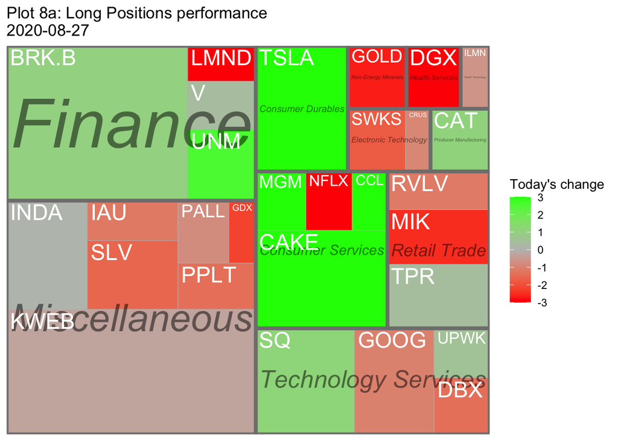

Short postions

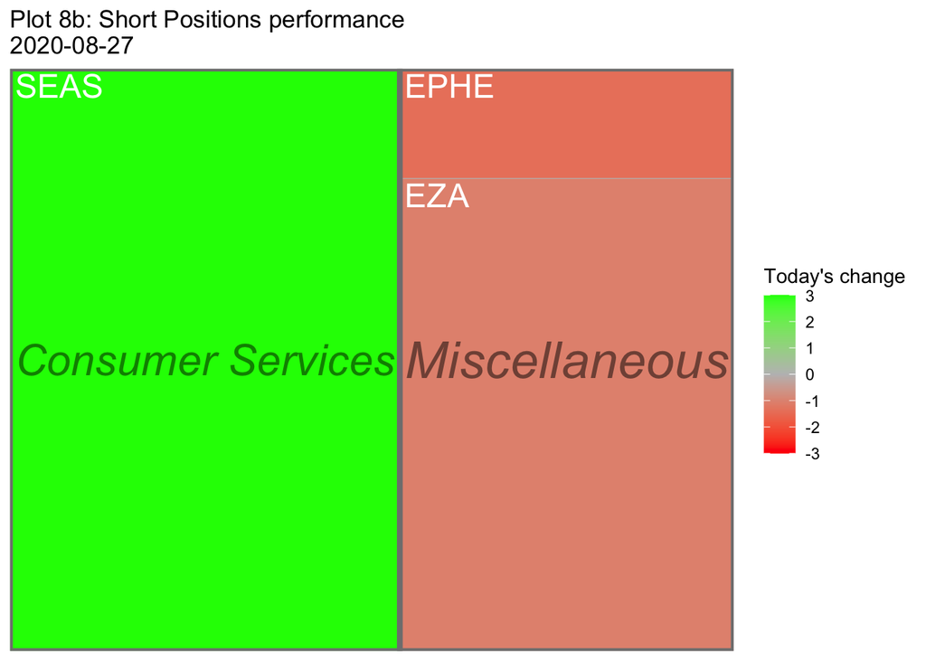

S&P 500 stocks colored by last day performance.

Outliers skew the colors, making the other stocks look pale. I restricted the colors to max of 3 and -3% change. Every stock having higher or lower than 3% change has the same color.

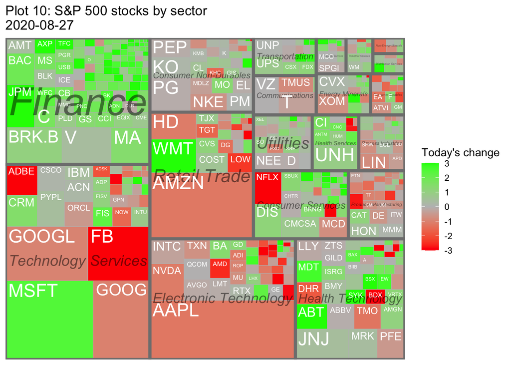

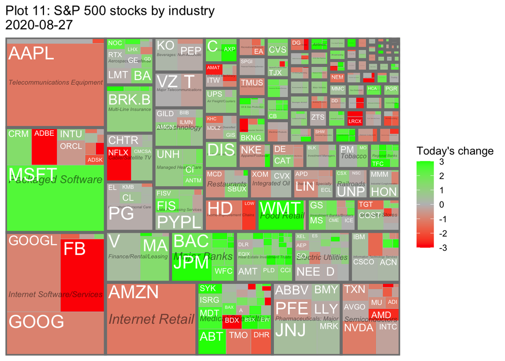